# Case Study 2

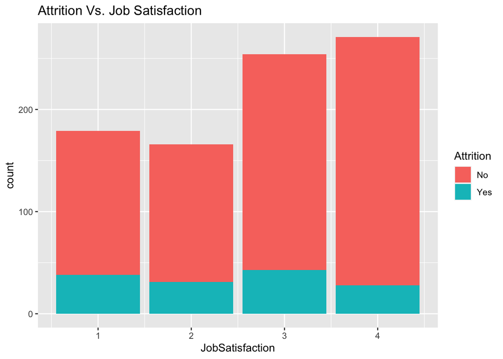

```r
### Attrition Vs. Job Satisfaction
employeeData %>%
  ggplot(aes(x=JobSatisfaction,fill=Attrition))+
  geom_bar()+
  ggtitle("Attrition Vs. Job Satisfaction")
```

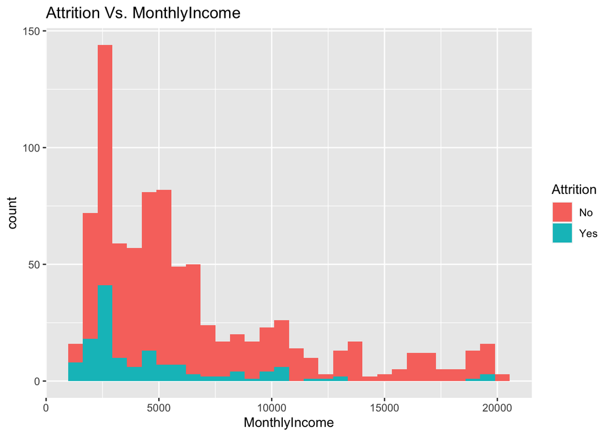

```r
### Attrition Vs. MonthlyIncome
employeeData %>% ggplot(aes(x=MonthlyIncome,fill=Attrition))+
  geom_histogram()+
  ggtitle("Attrition Vs. MonthlyIncome")
```

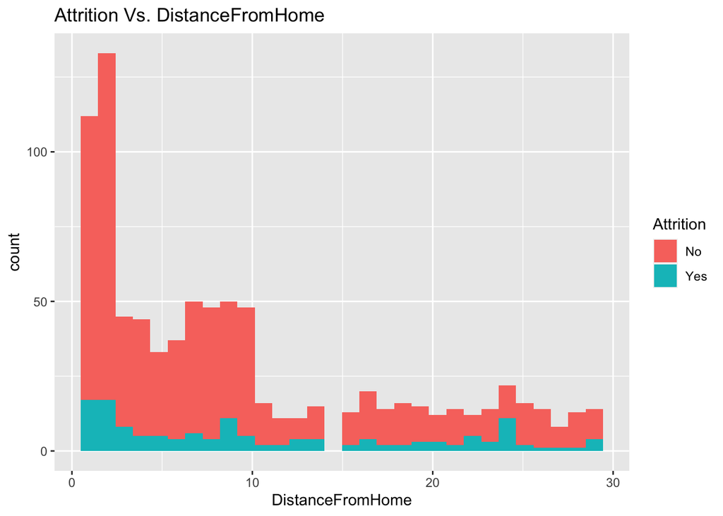

```r
### Attrition Vs. DistanceFromHome
employeeData %>%
  ggplot(aes(x=DistanceFromHome,fill=Attrition))+
  geom_histogram()+
  ggtitle("Attrition Vs. DistanceFromHome")
```

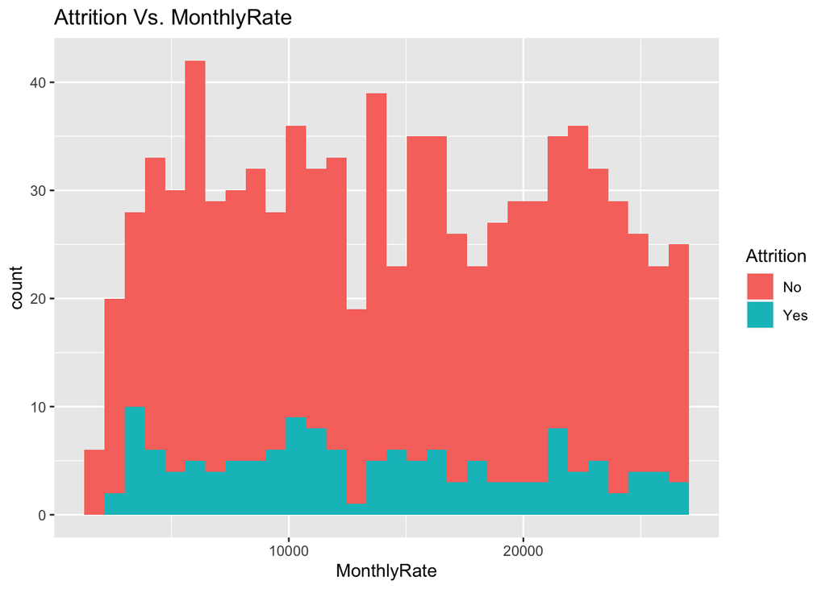

```r
### Attrition Vs. MonthlyRate
employeeData %>% ggplot(aes(x=MonthlyRate,fill=Attrition))+geom_histogram()+ggtitle("Attrition Vs. MonthlyRate")
```

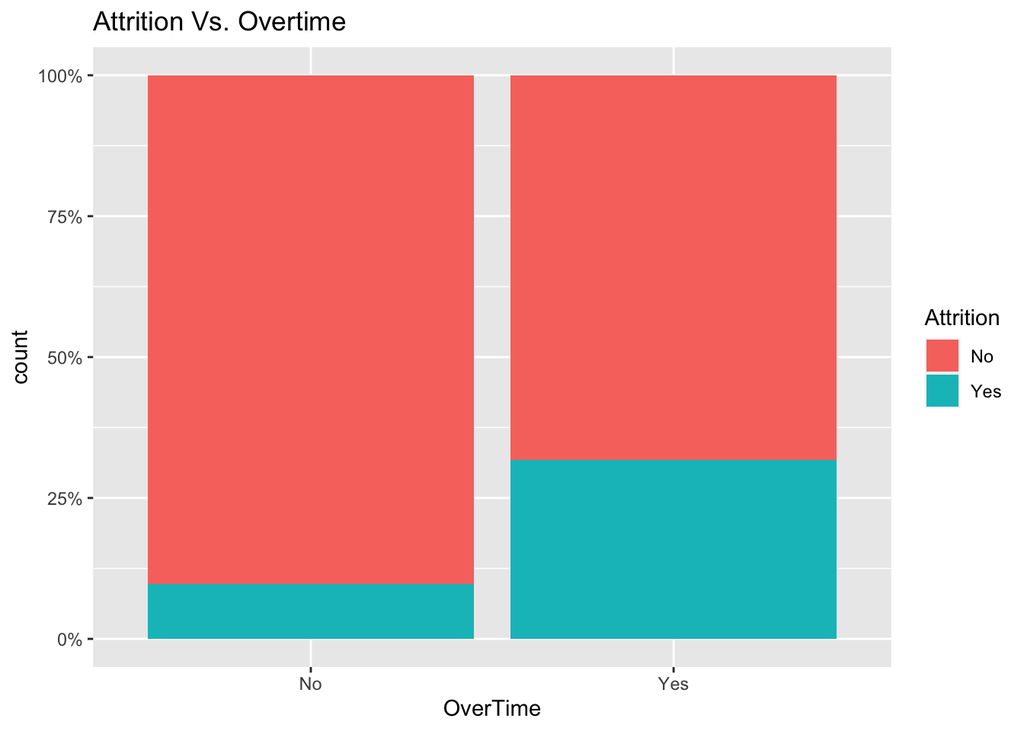

```r
### Attrition Vs. OverTime
employeeData %>%
  ggplot(aes(x=OverTime,fill=Attrition))+
  geom_bar(position="fill")+ggtitle("Attrition Vs. Overtime")+
  scale_y_continuous(labels = scales::percent)
```

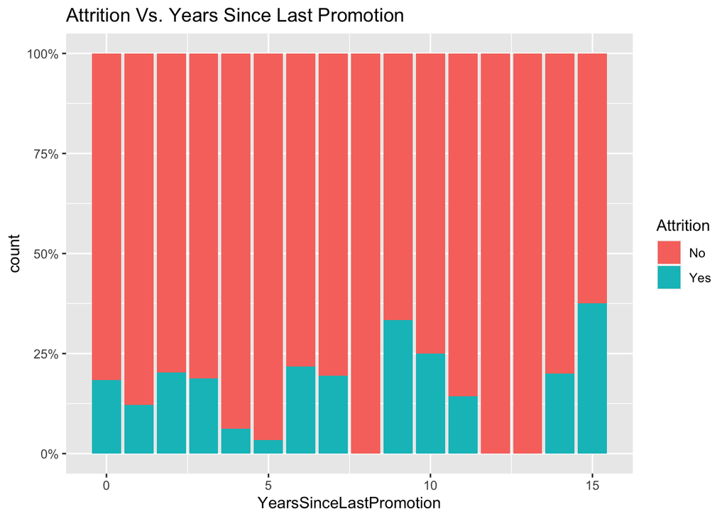

```r
### Attrition Vs. years Since last Promotion
employeeData %>%
  ggplot(aes(x=YearsSinceLastPromotion,fill=Attrition))+
  geom_bar(position="fill")+ggtitle("Attrition Vs. Years Since Last Promotion") +
  scale_y_continuous(labels = scales::percent)
```

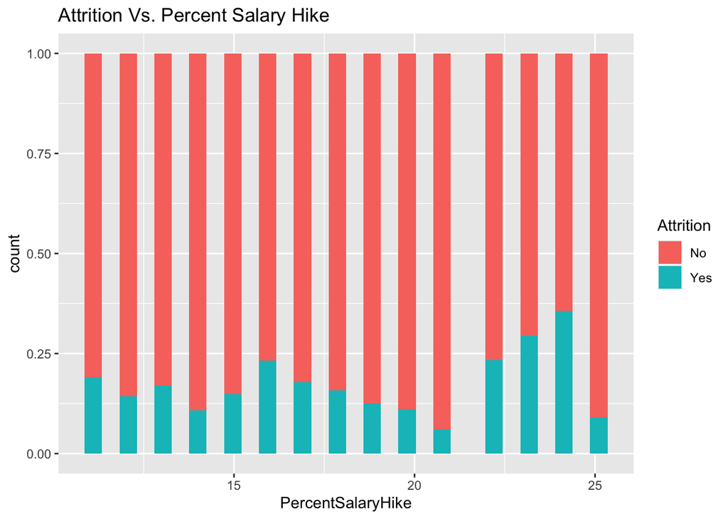

```r
### Attrition Vs. Salary Hike - NO
employeeData %>%
  ggplot(aes(x=PercentSalaryHike,fill=Attrition))+
  geom_histogram(position="fill")+
  ggtitle("Attrition Vs. Percent Salary Hike")
```

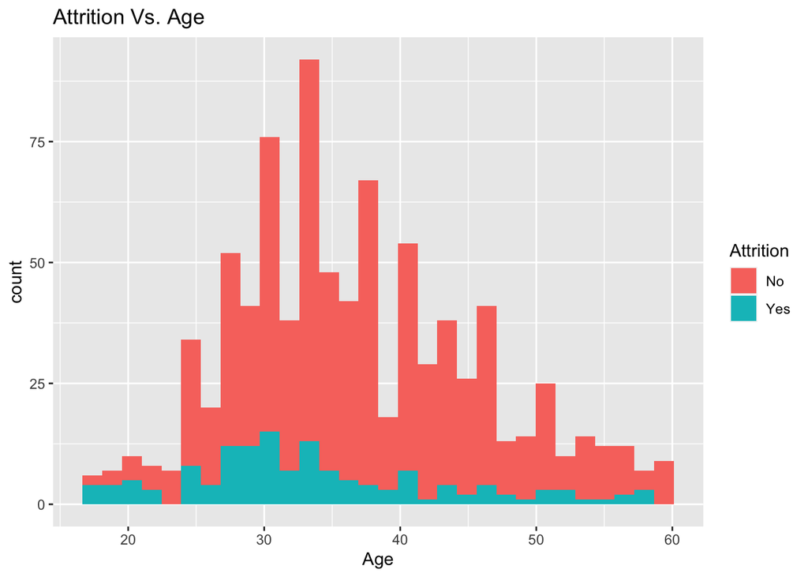

```r
### Attrition Vs. Age
employeeData %>%
  ggplot(aes(x=Age,fill=Attrition))+
  geom_histogram()+
  ggtitle("Attrition Vs. Age")
```

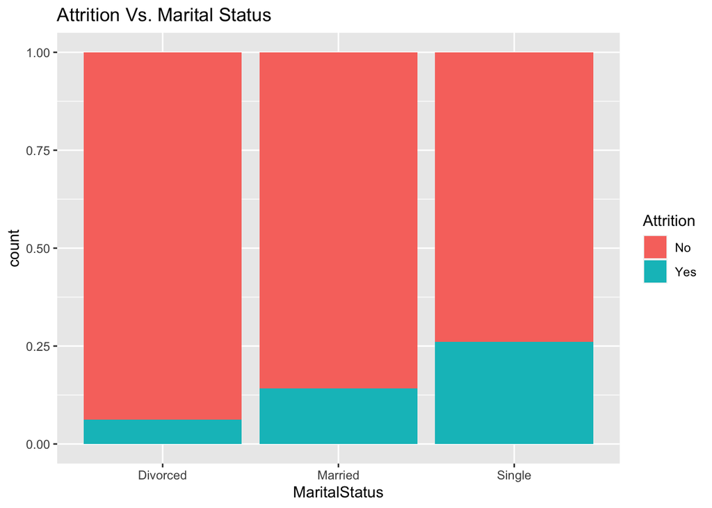

```r
### Attrition vs Marital Status
employeeData %>%
  ggplot(aes(x=MaritalStatus,fill=Attrition))+
  geom_bar(position="fill")+
  ggtitle("Attrition Vs. Marital Status")
```

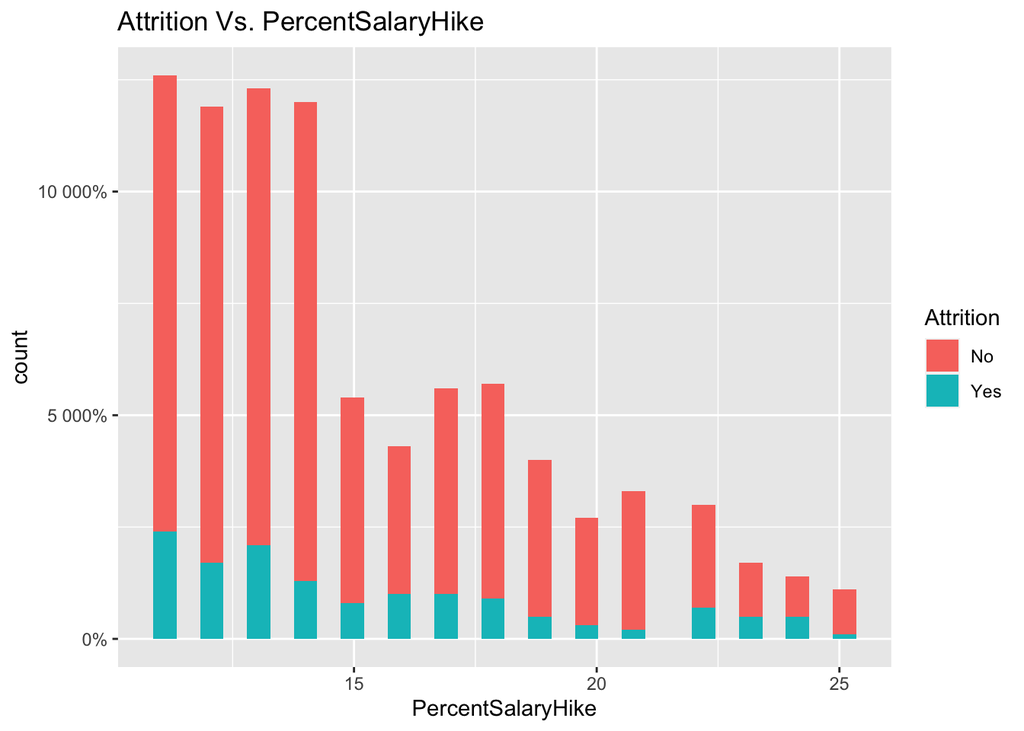

```r
### Attrition Vs. PercentSalaryHike
employeeData %>%
  ggplot(aes(x=PercentSalaryHike,fill=Attrition))+
  geom_histogram()+ggtitle("Attrition Vs. PercentSalaryHike")+
  scale_y_continuous(labels = scales::percent)
```

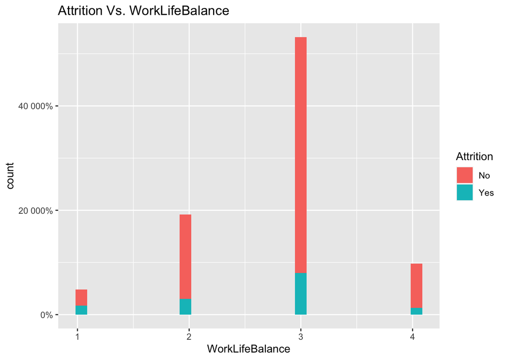

```r
### Attrition Vs. WorkLifeBalance
employeeData %>%
  ggplot(aes(x=WorkLifeBalance,fill=Attrition))+
  geom_histogram()+ggtitle("Attrition Vs. WorkLifeBalance")+
  scale_y_continuous(labels = scales::percent)
```

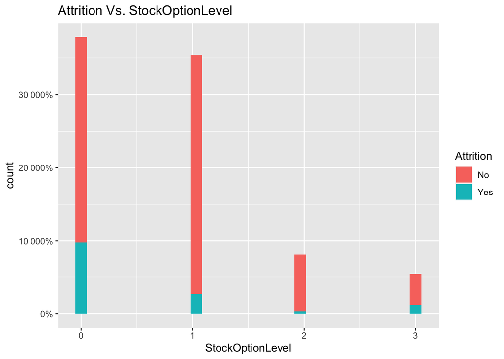

```r
### Attrition Vs. StockOptionLevel
employeeData %>%
  ggplot(aes(x=StockOptionLevel,fill=Attrition))+
  geom_histogram()+ggtitle("Attrition Vs. StockOptionLevel")+
  scale_y_continuous(labels = scales::percent)
```

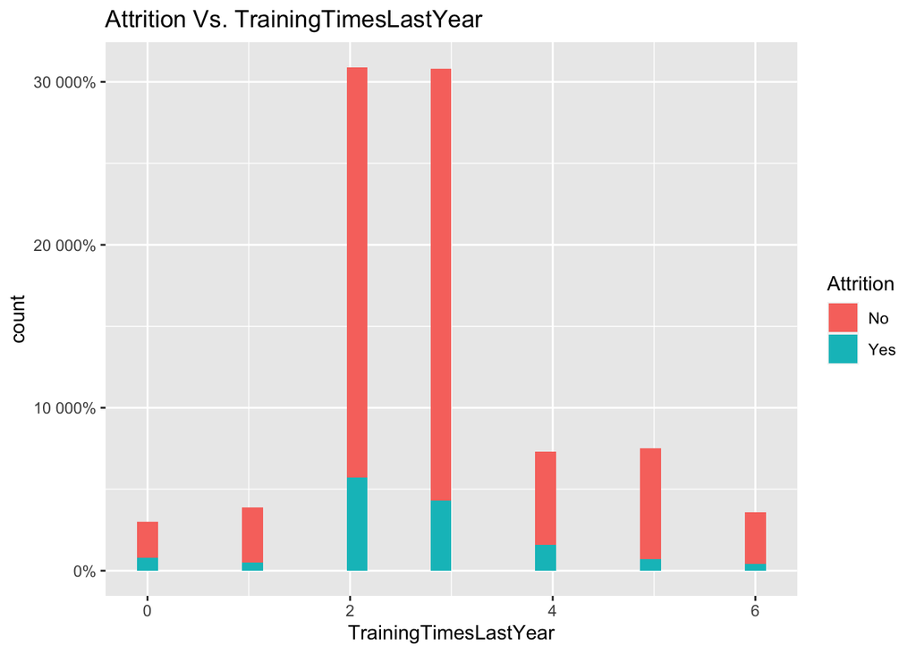

```r
### Attrition Vs. TrainingTimesLastYear
employeeData %>%
  ggplot(aes(x=TrainingTimesLastYear,fill=Attrition))+
  geom_histogram()+
  ggtitle("Attrition Vs. TrainingTimesLastYear")+
  scale_y_continuous(labels = scales::percent)
```

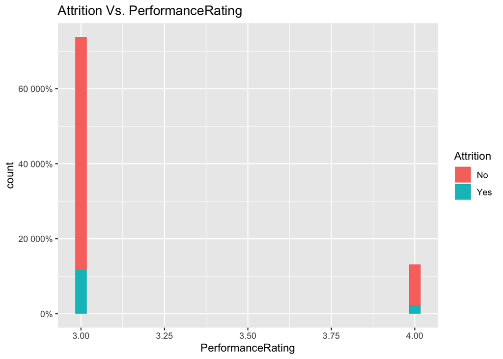

```r
### Attrition Vs. PerformanceRating
employeeData %>%
  ggplot(aes(x=PerformanceRating,fill=Attrition))+
  geom_histogram()+ggtitle("Attrition Vs. PerformanceRating")+
  scale_y_continuous(labels = scales::percent)
```

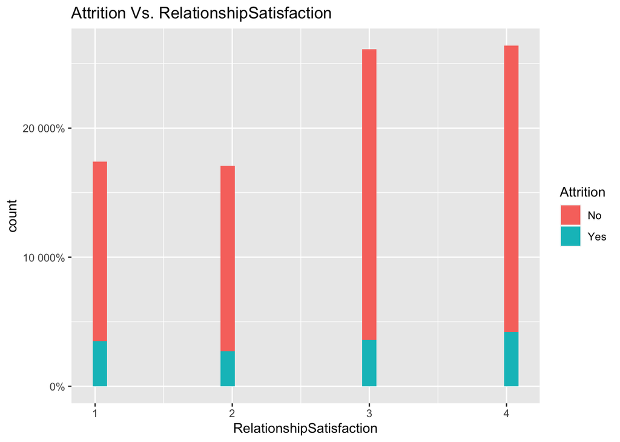

```r
### Attrition Vs. RelationshipSatisfaction
employeeData %>%
  ggplot(aes(x=RelationshipSatisfaction,fill=Attrition))+
  geom_histogram()+ggtitle("Attrition Vs. RelationshipSatisfaction")+
  scale_y_continuous(labels = scales::percent)
```

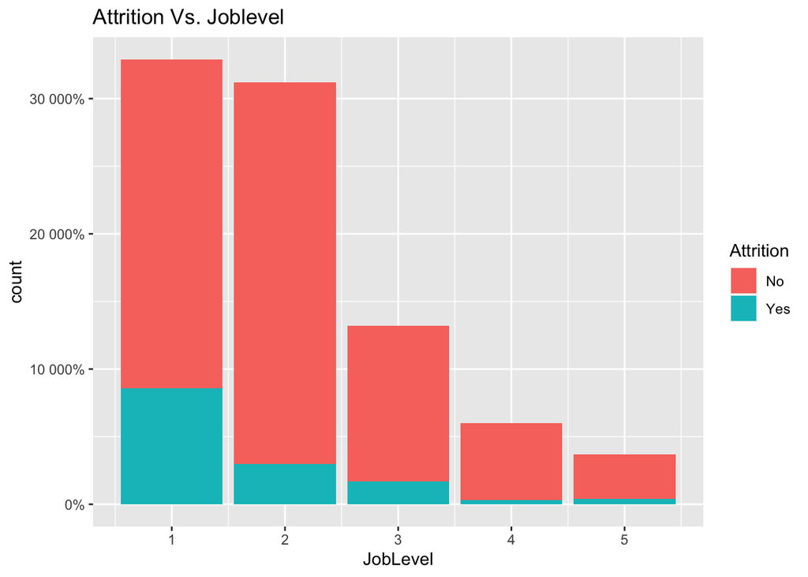

```r
### Attrition Vs. Joblevel
employeeData %>%
  ggplot(aes(x=JobLevel,fill=Attrition))+
  geom_bar()+ggtitle("Attrition Vs. Joblevel")+
  scale_y_continuous(labels = scales::percent)
```

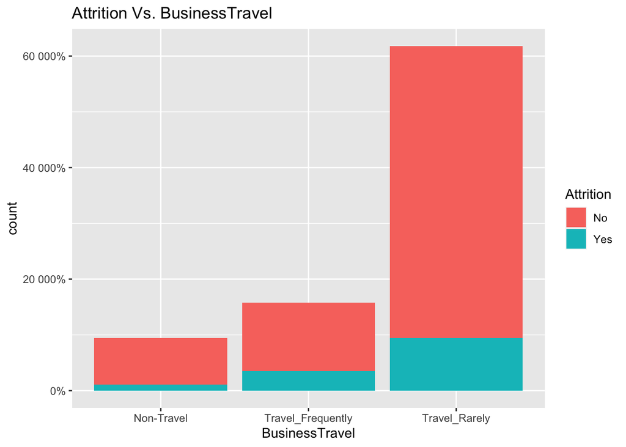

```r
### Attrition Vs. BusinessTravel
employeeData %>%
  ggplot(aes(x=BusinessTravel,fill=Attrition))+
  geom_bar()+ggtitle("Attrition Vs. BusinessTravel")+
  scale_y_continuous(labels = scales::percent)
```

```r
#### Monthly Income EDA
### Compare Incomes
employeeData %>% group_by(Attrition) %>% summarise(compareincomes=mean(MonthlyIncome))
```

```
## # A tibble: 2 × 2
##   Attrition compareincomes
##   <chr>              <dbl>
## 1 No                 6702
## 2 Yes                4765.
```

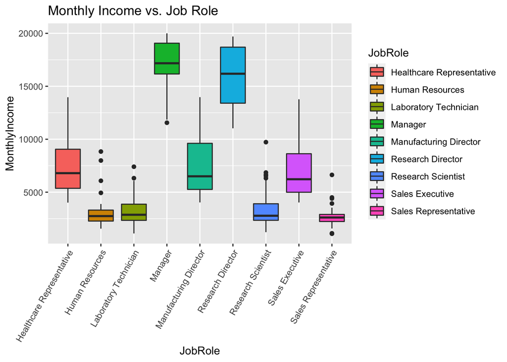

```r
### Job Role vs. Monthly Salary
employeeData %>%
  ggplot(aes(x=JobRole,y = MonthlyIncome, fill = JobRole))+
  geom_boxplot()+ggtitle("Monthly Income vs. Job Role")+
  theme(axis.text.x = element_text(angle = 60, vjust = 1, hjust=1))
```

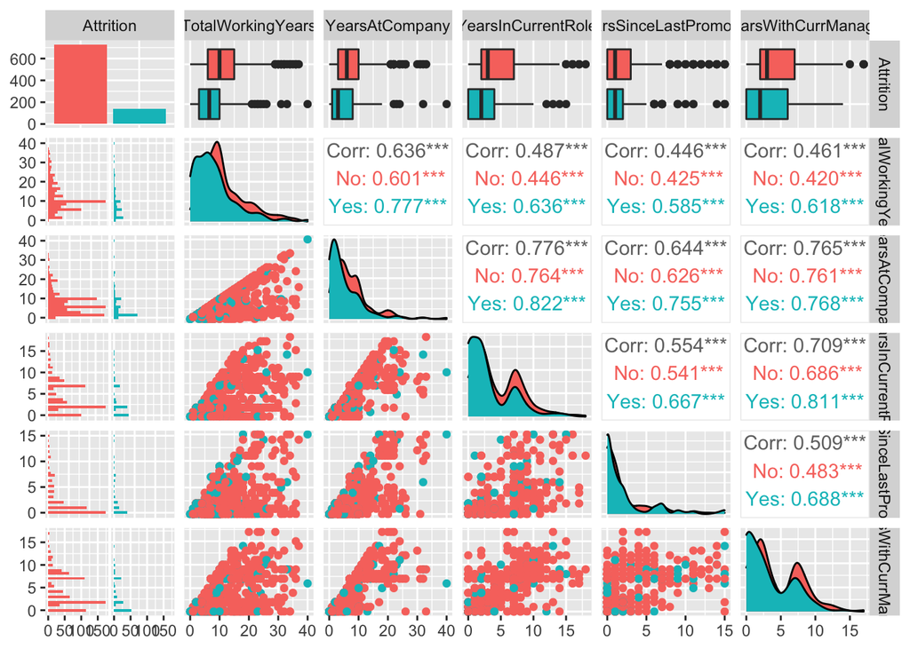

```r
ggpairs(employeeData[,c(3,30, 33:36)], aes(color = Attrition))
```

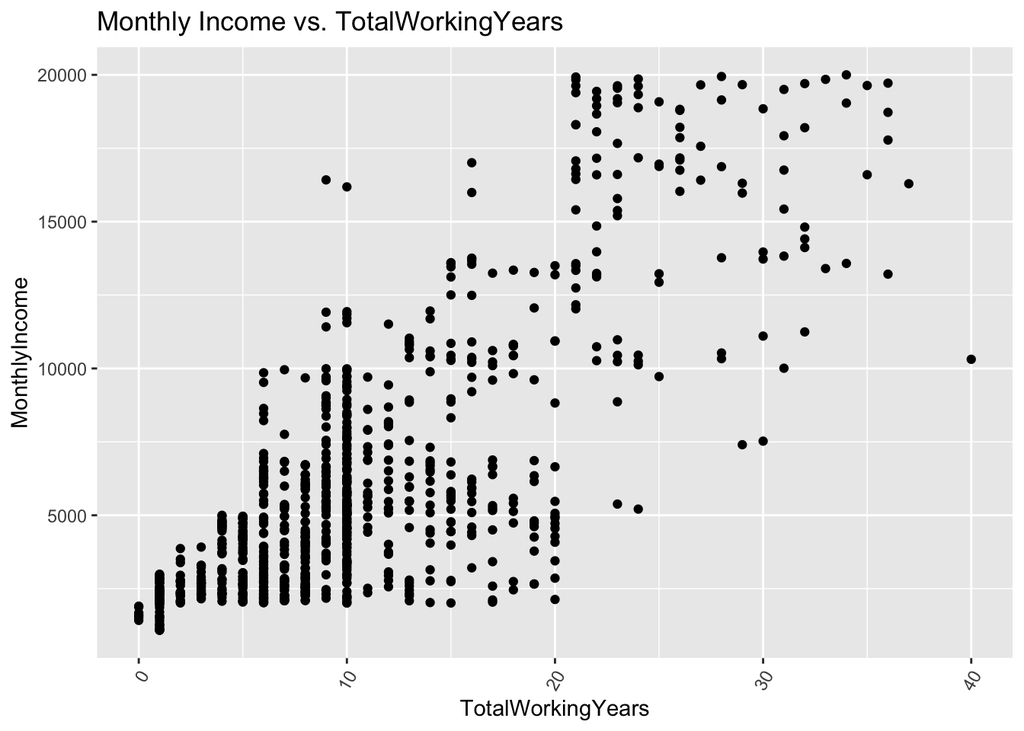

```r
employeeData %>%
  ggplot(aes(x=TotalWorkingYears,y = MonthlyIncome))+
  geom_point()+ggtitle("Monthly Income vs. TotalWorkingYears")+
  theme(axis.text.x = element_text(angle = 60, vjust = 1, hjust=1))
```

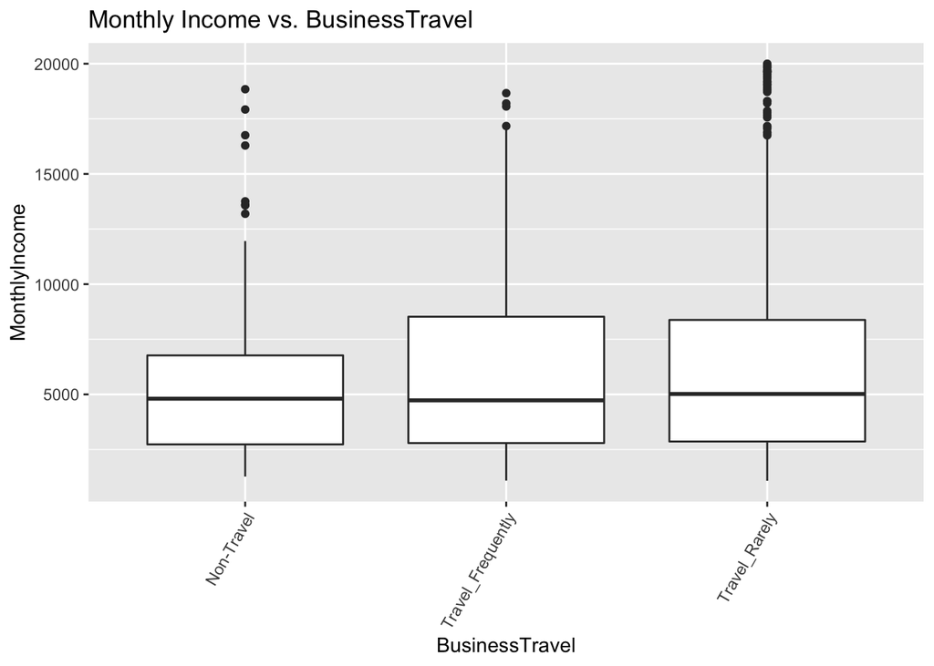

```r
employeeData %>%
  ggplot(aes(x=BusinessTravel,y = MonthlyIncome))+
  geom_boxplot()+ggtitle("Monthly Income vs. BusinessTravel")+
  theme(axis.text.x = element_text(angle = 60, vjust = 1, hjust=1))
```

## KNN Model

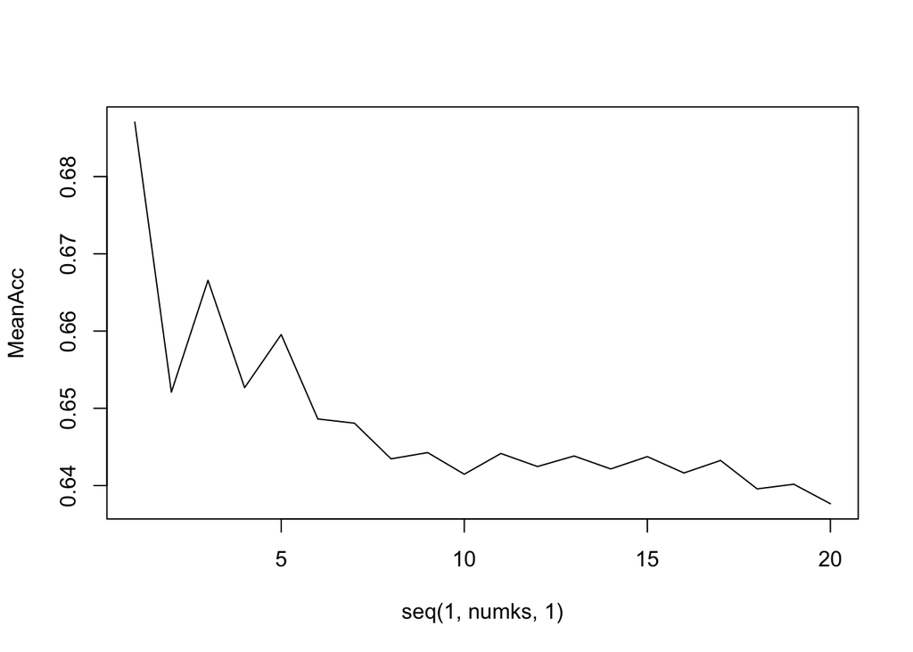

```r
### KNN Model

## Classify
employeeData2 = employeeData
employeeData2$Attrition = as.factor(employeeData2$Attrition)

# create dataset for KNN model
model = employeeData2[,-c(1,4,5,6,8,9,10,11,12,13,14,17,19,21,23,24,28,38)]

# oversample to make up for imbalance in dataset
model = oversample(model,classAttr = "Attrition",method = "ADASYN")

## ML
set.seed(124) # Changed seed multiple times to see how high it can go
iterations = 200
numks = 20
splitPerc = .70
masterAcc = matrix(nrow = iterations, ncol = numks)
for(j in 1:iterations)
{
  trainIndices = sample(1:dim(model)[1],round(splitPerc * dim(model)[1]))
  train = model[trainIndices,]
  test = model[-trainIndices,]
  for(i in 1:numks)
  {
    classifications = knn(train[,-c(2)],test[,-c(2)],train$Attrition, prob = TRUE, k = i)
    table(classifications,test$Attrition)
    CM = confusionMatrix(table(classifications,test$Attrition))
    masterAcc[j,i] = CM$overall[1]
  }

}
MeanAcc = colMeans(masterAcc)
plot(seq(1,numks,1),MeanAcc, type = "l")
```

```r
which.max(MeanAcc)
```

```
## [1] 1
```

```r
max(MeanAcc)
```

```
## [1] 0.687037
```

## Confusion Matrix for KNN model

```r
classifications = knn(train[,-c(2)],test[,-c(2)],train$Attrition, prob = TRUE, k = 3)
table(classifications,test$Attrition)
```

```
##
## classifications  No Yes
##             No  142  72
##             Yes  59 159
```

```r
CM = confusionMatrix(table(classifications,test$Attrition))
CM
```

```
## Confusion Matrix and Statistics
##
##
## classifications  No Yes
##             No  142  72
##             Yes  59 159
##
##                Accuracy : 0.6968
##                  95% CI : (0.651, 0.7398)
##     No Information Rate : 0.5347
##     P-Value [Acc > NIR] : 4.683e-12
##
##                   Kappa : 0.3931
##
##  Mcnemar's Test P-Value : 0.2944
##
##             Sensitivity : 0.7065
##             Specificity : 0.6883
##          Pos Pred Value : 0.6636
##          Neg Pred Value : 0.7294
##              Prevalence : 0.4653
##          Detection Rate : 0.3287
##    Detection Prevalence : 0.4954
##       Balanced Accuracy : 0.6974
##
##        'Positive' Class : No
##
```

## Naive-Bayes Model

Now, want to use Naive-bayes to build our model. This model yielded us much better results with an accuracy of 0.8884, a Specificity of 0.9019 and sensitivity 0.8750. As a result, we find this model to be quite accurate. Therefore, the Naive-bayes model that we’ve built to predict attriton on the test dataset.

```r
set.seed(25)
naive_data=employeeData

naive_data$Attrition = as.factor(naive_data$Attrition)

model2 = naive_data[,-c(1,2,4,5,7,9,10,11,13,
                        14,21:23,25,28,37,38)]

## get data ready for oversampling
#Convert all character variables to factors
model2 = model2 %>%
  mutate_if(sapply(model2, is.character), as.factor)
#Convert all character variables to integer
model2 = model2 %>%
  mutate_if(sapply(model2, is.factor), as.integer)

#oversample
model2 = oversample(model2,classAttr = "Attrition",method = "ADASYN")

#revert interger back to factor
model2 = model2 %>%
  mutate_if(sapply(model2, is.integer), as.factor)

#change Attrition back to character and factor
model2$Attrition <- (ifelse(model2$Attrition==1,"No","Yes"))
model2$Attrition <- as.factor(model2$Attrition)

model2$Attrition = as.factor(model2$Attrition)
trainIndices = sample(1:dim(model2)[1],round(.70 * dim(model2)[1]))
train = model2[trainIndices,]
test = model2[-trainIndices,]

classifier1 = naiveBayes(Attrition~., data =model2)

pred = predict(classifier1,newdata=test)
CM = confusionMatrix(table(test$Attrition,pred))

CM
```

```
## Confusion Matrix and Statistics
##
##      pred
##        No Yes
##   No  189  21
##   Yes  27 193
##
##                Accuracy : 0.8884
##                  95% CI : (0.8547, 0.9165)
##     No Information Rate : 0.5023
##     P-Value [Acc > NIR] : <2e-16
##
##                   Kappa : 0.7768
##
##  Mcnemar's Test P-Value : 0.4705
##
##             Sensitivity : 0.8750
##             Specificity : 0.9019
##          Pos Pred Value : 0.9000
##          Neg Pred Value : 0.8773
##              Prevalence : 0.5023
##          Detection Rate : 0.4395
##    Detection Prevalence : 0.4884
##       Balanced Accuracy : 0.8884
##
##        'Positive' Class : No
##
```

## Read in NoAttrition dataset

```r
employee_noattri = read.csv("CaseStudy2CompSet No Attrition (1).csv")
employee_noattri
```

[output not shown]

[output cut: 2393 more lines]

## Predict Attrition

In this code block, we will use our Naive-Bayes model to predict attrition and store it in a variable.

```r
# Convert overtime to binary
employee_noattri$cleanOverTime = ifelse(employee_noattri$OverTime=="Yes",1,0)

employee_noattri = employee_noattri %>%
  mutate_if(sapply(employee_noattri, is.character), as.factor)
#Convert all character variables to integer
employee_noattri = employee_noattri %>%
  mutate_if(sapply(employee_noattri, is.factor), as.integer)
employee_noattri = employee_noattri %>%
  mutate_if(sapply(employee_noattri, is.integer), as.factor)


attrition_pred = predict(classifier1, employee_noattri)
attrition_pred
```

```
##   [1] No  No  Yes No  No  No  No  No  No  Yes No  Yes No  No  No  No  No  No
##  [19] No  No  Yes No  No  No  No  No  Yes Yes Yes Yes No  No  No  No  Yes No
##  [37] No  No  No  No  No  No  No  No  Yes No  No  Yes Yes No  No  Yes No  No
##  [55] No  No  No  No  No  No  No  No  Yes No  No  No  No  No  No  No  Yes No
##  [73] No  No  No  Yes No  No  No  No  No  No  Yes No  No  No  No  No  No  Yes
##  [91] No  No  No  Yes No  No  No  No  Yes Yes No  No  No  No  Yes No  No  No
## [109] No  No  No  No  No  No  No  No  No  No  Yes No  No  No  No  No  No  No
## [127] Yes No  No  No  No  No  No  Yes No  No  No  Yes No  Yes No  No  No  No
## [145] No  No  Yes Yes No  No  No  No  No  No  No  Yes No  No  Yes No  Yes Yes
## [163] Yes No  No  No  No  No  No  No  Yes No  Yes Yes No  No  Yes Yes No  No
## [181] Yes No  No  No  No  No  No  Yes No  No  No  No  No  No  Yes No  No  No
## [199] No  No  No  No  No  No  No  No  No  No  No  No  Yes No  No  No  No  No
## [217] Yes No  No  No  No  No  No  No  No  No  Yes No  No  No  Yes No  No  Yes
## [235] No  No  Yes No  No  No  No  No  No  No  No  No  No  No  No  Yes Yes No
## [253] No  Yes No  No  No  No  No  No  No  No  No  No  No  No  No  No  Yes No
## [271] No  Yes No  Yes Yes No  Yes No  Yes Yes No  No  No  No  Yes Yes No  Yes
## [289] No  Yes No  No  Yes No  Yes No  No  Yes No  No
## Levels: No Yes
```

## Add attrition prediction to dataset

```r
employee_noattri$AttritionPred = attrition_pred
employee_noattri
```

[output not shown]

[output cut: 2393 more lines]

## Write csv file for attrition prediction

```r
filtered_noattrition = employee_noattri %>%
  select(ID, AttritionPred) %>% arrange(ID)
filtered_noattrition
```

```
##       ID AttritionPred
## 1   1171            No
## 2   1172            No
## 3   1173           Yes
## 4   1174            No
## 5   1175            No
## 6   1176            No
## 7   1177            No
## 8   1178            No
## 9   1179            No
## 10  1180           Yes
## 11  1181            No
## 12  1182           Yes
## 13  1183            No
## 14  1184            No
```

[output cut: 286 more lines]

```r
write.csv(filtered_noattrition, "Case2PredictionsChang Attrition.csv")
```

## Read in NoSalary dataset

```r
employee_nosalary = read_excel("CaseStudy2CompSet No Salary (2).xlsx")
```

## Finding Variables for Best Linear Regression Model

We will create a linear regression model to test all of the variables to decide on which one will be selected for our final linear regression model.To incoporate all the variables, I will be creating dummy columns to make various columns binary, I can use them in this model.

```r
employeeData3 = employeeData2
employeeData3 = dummy_cols(employeeData3,
                           select_columns = c("BusinessTravel","Department",
                                              "EducationField","Gender",
                                              "JobRole", "MaritalStatus" ))

employeeData3$JobRole_Others = ifelse(employeeData3$JobRole_Manager == 1|employeeData3$`JobRole_Research Director` == 1|
                                        employeeData3$`JobRole_Sales Executive` == 1, 0, 1)
employeeData3$BusinessTravel_Others = ifelse(employeeData3$`BusinessTravel_Non-Travel` == 1, 0, 1)

employeeData3[,c(39:66)] = employeeData3[,c(39:66)] %>%
  mutate_if(sapply(employeeData3[,c(39:66)], is.numeric), as.factor)

lm_salarydf = employeeData3[,c(2,5,7,8,12,14,15,16,18, 20,
                              21,25,26,27,29,30, 31,32,33,34,
                              35,36,37, 39:64)]

lmsalary_model = lm(MonthlyIncome~.,
                    data = lm_salarydf)
summary(lmsalary_model)
```

```
##
## Call:
## lm(formula = MonthlyIncome ~ ., data = lm_salarydf)
##
## Residuals:
##     Min      1Q  Median      3Q     Max
## -3632.4  -659.6     2.9   620.1  4165.7
##
## Coefficients: (6 not defined because of singularities)
##                                        Estimate Std. Error t value Pr(>|t|)
## (Intercept)                           3.819e+02  5.470e+02   0.698  0.48531
## Age                                  -1.510e+00  5.630e+00  -0.268  0.78867
## DailyRate                             1.450e-01  9.122e-02   1.590  0.11222
## DistanceFromHome                     -6.536e+00  4.531e+00  -1.442  0.14956
## Education                            -3.259e+01  3.689e+01  -0.883  0.37735
## EnvironmentSatisfaction              -6.510e+00  3.349e+01  -0.194  0.84592
## HourlyRate                           -3.380e-01  1.824e+00  -0.185  0.85307
## JobInvolvement                        1.065e+01  5.236e+01   0.203  0.83894
## JobLevel                              2.785e+03  8.341e+01  33.394  < 2e-16 ***
## JobSatisfaction                       2.314e+01  3.295e+01   0.702  0.48276
## MonthlyRate                          -9.379e-03  5.141e-03  -1.824  0.06844 .
## PercentSalaryHike                     2.532e+01  1.582e+01   1.600  0.10989
## PerformanceRating                    -3.237e+02  1.615e+02  -2.004  0.04537 *
## RelationshipSatisfaction              1.514e+01  3.309e+01   0.457  0.64749
## StockOptionLevel                      4.146e+00  5.682e+01   0.073  0.94185
## TotalWorkingYears                     5.204e+01  1.043e+01   4.990 7.37e-07 ***
## TrainingTimesLastYear                 2.171e+01  2.904e+01   0.748  0.45497
## WorkLifeBalance                      -3.909e+01  5.139e+01  -0.761  0.44706
## YearsAtCompany                       -5.591e+00  1.321e+01  -0.423  0.67218
## YearsInCurrentRole                    4.987e+00  1.699e+01   0.294  0.76916
## YearsSinceLastPromotion               3.160e+01  1.522e+01   2.077  0.03813 *
## YearsWithCurrManager                 -2.652e+01  1.666e+01  -1.591  0.11190
## cleanOverTime                         2.343e+00  8.080e+01   0.029  0.97687
## `BusinessTravel_Non-Travel`1         -3.787e+02  1.198e+02  -3.160  0.00163 **
## BusinessTravel_Travel_Frequently1    -1.773e+02  9.700e+01  -1.827  0.06801 .
## BusinessTravel_Travel_Rarely1                NA         NA      NA       NA
## `Department_Human Resources`1         4.256e+02  4.871e+02   0.874  0.38258
## `Department_Research & Development`1  5.625e+02  3.307e+02   1.701  0.08936 .
## Department_Sales1                            NA         NA      NA       NA
## `EducationField_Human Resources`1    -7.526e+01  3.841e+02  -0.196  0.84472
```

[output cut: 10 more lines]

```
## JobRole_Manager1                      4.186e+03  3.565e+02  11.744  < 2e-16 ***
## `JobRole_Manufacturing Director`1     7.693e+01  3.884e+02   0.198  0.84304
## `JobRole_Research Director`1          3.960e+03  4.352e+02   9.098  < 2e-16 ***
## `JobRole_Research Scientist`1        -4.370e+02  3.699e+02  -1.181  0.23775
## `JobRole_Sales Executive`1            4.251e+02  1.904e+02   2.233  0.02583 *
## `JobRole_Sales Representative`1              NA         NA      NA       NA
## MaritalStatus_Divorced1              -2.900e+01  1.343e+02  -0.216  0.82905
## MaritalStatus_Married1                4.348e+01  1.023e+02   0.425  0.67089
## MaritalStatus_Single1                        NA         NA      NA       NA
## ---
## Signif. codes:  0 '***' 0.001 '**' 0.01 '*' 0.05 '.' 0.1 ' ' 1
##
## Residual standard error: 1056 on 827 degrees of freedom
## Multiple R-squared:  0.9498, Adjusted R-squared:  0.9472
## F-statistic: 372.3 on 42 and 827 DF,  p-value: < 2.2e-16
```

## Creating Linear Regression Model

```r
lm_salarydf = employeeData3[,c(16, 20,21, 26, 30, 35,39:44, 53:61)] # 39-44 is Business Travel, 53-61 is Jobe Role

lmsalary_model2 = lm(MonthlyIncome~.,
                    data = lm_salarydf)
summary(lmsalary_model2)
```

```
##
## Call:
## lm(formula = MonthlyIncome ~ ., data = lm_salarydf)
##
## Residuals:
##     Min      1Q  Median      3Q     Max
## -3777.9  -633.7    -4.8   619.2  4107.0
##
## Coefficients: (3 not defined because of singularities)
##                                        Estimate Std. Error t value Pr(>|t|)
## (Intercept)                           1.448e+02  3.627e+02   0.399 0.689770
## JobLevel                              2.779e+03  8.153e+01  34.086  < 2e-16 ***
## MonthlyRate                          -9.052e-03  5.056e-03  -1.790 0.073748 .
## PerformanceRating                    -1.379e+02  1.004e+02  -1.373 0.170137
## TotalWorkingYears                     4.499e+01  8.342e+00   5.393 8.99e-08 ***
## YearsSinceLastPromotion               1.564e+01  1.275e+01   1.227 0.220322
## `BusinessTravel_Non-Travel`1         -3.983e+02  1.173e+02  -3.395 0.000718 ***
## BusinessTravel_Travel_Frequently1    -1.972e+02  9.512e+01  -2.073 0.038450 *
## BusinessTravel_Travel_Rarely1                NA         NA      NA       NA
## `Department_Human Resources`1         3.978e+02  4.425e+02   0.899 0.368936
## `Department_Research & Development`1  5.527e+02  3.232e+02   1.710 0.087578 .
## Department_Sales1                            NA         NA      NA       NA
## `JobRole_Healthcare Representative`1 -1.113e+02  3.865e+02  -0.288 0.773496
## `JobRole_Human Resources`1           -3.424e+02  5.078e+02  -0.674 0.500233
## `JobRole_Laboratory Technician`1     -7.331e+02  3.664e+02  -2.001 0.045706 *
## JobRole_Manager1                      4.156e+03  3.511e+02  11.837  < 2e-16 ***
## `JobRole_Manufacturing Director`1     1.860e+01  3.840e+02   0.048 0.961381
## `JobRole_Research Director`1          3.921e+03  4.295e+02   9.129  < 2e-16 ***
## `JobRole_Research Scientist`1        -4.694e+02  3.655e+02  -1.284 0.199417
## `JobRole_Sales Executive`1            3.681e+02  1.852e+02   1.988 0.047168 *
## `JobRole_Sales Representative`1              NA         NA      NA       NA
## ---
## Signif. codes:  0 '***' 0.001 '**' 0.01 '*' 0.05 '.' 0.1 ' ' 1
##
## Residual standard error: 1053 on 852 degrees of freedom
## Multiple R-squared:  0.9485, Adjusted R-squared:  0.9475
## F-statistic: 923.9 on 17 and 852 DF,  p-value: < 2.2e-16
```

```r
RSS = c(crossprod(lmsalary_model2$residuals))
MSE = RSS / length(lmsalary_model2$residuals)
RMSE = sqrt(MSE)
sig2 = RSS / lmsalary_model2$df.residual

RMSE
```

```
## [1] 1042.313
```

## Predicting Salary

```r
# create dummy variables
employee_nosalary= dummy_cols(employee_nosalary,
                           select_columns = c("BusinessTravel","Department",
                                              "EducationField","Gender",
                                              "JobRole", "MaritalStatus" ))

employee_nosalary$cleanOverTime = ifelse(employee_nosalary$OverTime=="Yes",1,0)
employee_nosalary$JobRole_Others = ifelse(employee_nosalary$JobRole_Manager == 1|
                                            employee_nosalary$`JobRole_Research Director` ==1|
                                            employee_nosalary$`JobRole_Sales Executive` == 1, 0, 1)
employee_nosalary$BusinessTravel_Others = ifelse(employee_nosalary$`BusinessTravel_Non-Travel` == 1, 0, 1)

# change dummy variables to factors
employee_nosalary[,c(36:63)] = employee_nosalary[,c(36:63)] %>%
  mutate_if(sapply(employee_nosalary[,c(36:63)], is.numeric), as.factor)

# predict salary
salary_pred = predict(lmsalary_model2, employee_nosalary)
```

## Adding Column to No Salary Dataset and Exporting as .csv File

```r
#salary_pred = unlist(salary_pred)

employee_nosalary$SalaryPred =salary_pred
head(employee_nosalary)
```

```
## # A tibble: 6 × 65
##      ID   Age Attrition Busine…¹ Daily…² Depar…³ Dista…⁴ Educa…⁵ Educa…⁶ Emplo…⁷
##   <dbl> <dbl> <chr>     <chr>      <dbl> <chr>     <dbl>   <dbl> <chr>     <dbl>
## 1   871    43 No        Travel_…    1422 Sales         2       4 Life S…       1
## 2   872    33 No        Travel_…     461 Resear…      13       1 Life S…       1
## 3   873    55 Yes       Travel_…     267 Sales        13       4 Market…       1
## 4   874    36 No        Non-Tra…    1351 Resear…       9       4 Life S…       1
## 5   875    27 No        Travel_…    1302 Resear…      19       3 Other         1
## 6   876    39 Yes       Travel_…     895 Sales         5       3 Techni…       1
## # … with 55 more variables: EmployeeNumber <dbl>,
## #   EnvironmentSatisfaction <dbl>, Gender <chr>, HourlyRate <dbl>,
## #   JobInvolvement <dbl>, JobLevel <dbl>, JobRole <chr>, JobSatisfaction <dbl>,
## #   MaritalStatus <chr>, MonthlyRate <dbl>, NumCompaniesWorked <dbl>,
## #   Over18 <chr>, OverTime <chr>, PercentSalaryHike <dbl>,
## #   PerformanceRating <dbl>, RelationshipSatisfaction <dbl>,
## #   StandardHours <dbl>, StockOptionLevel <dbl>, TotalWorkingYears <dbl>, …
## # ℹ Use `colnames()` to see all variable names
```

```r
filtered_nosalary = employee_nosalary %>% select(ID, SalaryPred) %>% arrange(ID)
filtered_nosalary
```

```
## # A tibble: 300 × 2
##       ID SalaryPred
##    <dbl>      <dbl>
##  1   871      5572.
##  2   872      2662.
##  3   873     12258.
##  4   874      1935.
##  5   875      2497.
##  6   876      6114.
##  7   877      5479.
##  8   878      1887.
##  9   879      2506.
## 10   880     12502.
## # … with 290 more rows
## # ℹ Use `print(n = ...)` to see more rows
```

## Create csv file with salary predictions

```r
write.csv(filtered_nosalary, "Case2PredictionsChang Salary.csv")
```